# L5 GNP AR Model

FIN 3380

# Set working directory

```r
setwd("C:/Users/siche/Documents/teaching/Introduction to Financial Data Analysis/L5")
library(dplyr)
library(zoo)
```

# Step 1. Load the GNP data, and visualise the GNP and its growth

#### Read the gnp data into R from txt file.

```r
da = as_tibble(read.table("q-gnp4710.txt",header=T))
head(da)
```

```
## # A tibble: 6 x 4
##    Year   Mon   Dat VALUE
##   <int> <int> <int> <dbl>
## 1  1947     1     1  238.
## 2  1947     4     1  242.
## 3  1947     7     1  246.
## 4  1947    10     1  256.
## 5  1948     1     1  262.
## 6  1948     4     1  269.
```

#### Calculate the gnp growth use log return, since gnp growth is likely to be exponential, we take a log of the level to see the trend of it.

```r
da = da %>% mutate(lg = log(VALUE),
                   gnp.g = lg - lag(lg,1)) %>%
  na.omit()
head(da)
```

```
## # A tibble: 6 x 6
##    Year   Mon   Dat VALUE    lg  gnp.g
##   <int> <int> <int> <dbl> <dbl>  <dbl>
## 1  1947     4     1  242.  5.49 0.0142
## 2  1947     7     1  246.  5.50 0.0168
## 3  1947    10     1  256.  5.54 0.0399
## 4  1948     1     1  262.  5.57 0.0236
## 5  1948     4     1  269.  5.59 0.0264
## 6  1948     7     1  275.  5.62 0.0243
```

```r
da = da %>% mutate(date = as.yearmon(paste0(Year,"-",Mon)))
head(da)
```

```
## # A tibble: 6 x 7
##    Year   Mon   Dat VALUE    lg  gnp.g date
##   <int> <int> <int> <dbl> <dbl>  <dbl> <yearmon>
## 1  1947     4     1  242.  5.49 0.0142 Apr 1947
## 2  1947     7     1  246.  5.50 0.0168 Jul 1947
## 3  1947    10     1  256.  5.54 0.0399 Oct 1947
## 4  1948     1     1  262.  5.57 0.0236 Jan 1948
## 5  1948     4     1  269.  5.59 0.0264 Apr 1948
## 6  1948     7     1  275.  5.62 0.0243 Jul 1948
```

#### Visualise the level of GNP and its quarterly growth

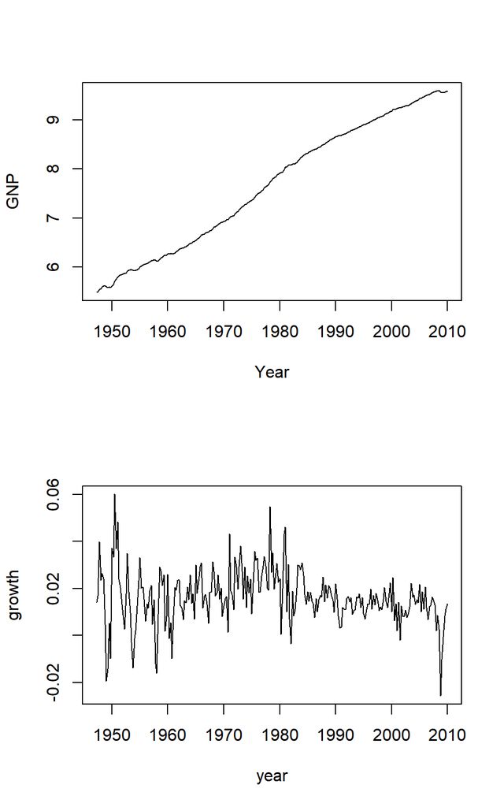

```r
par(mfcol=c(2,1))
with(da,plot(lg~date,xlab="Year",ylab="GNP",type="l"))
with(da,plot(date,gnp.g,type="l",xlab="year",ylab="growth"))
```

# Step 2. Look into the PACF to select the AR model order

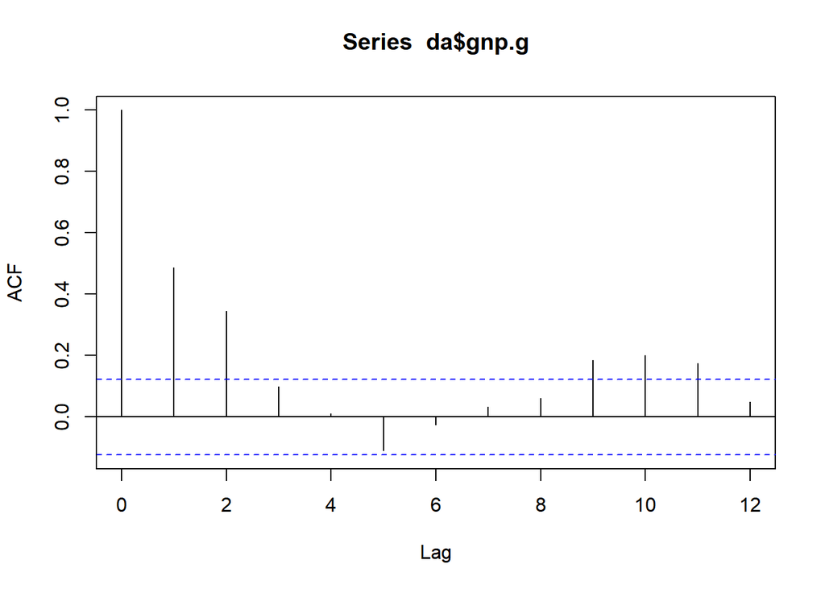

```r
acf(da$gnp.g,lag=12)
```

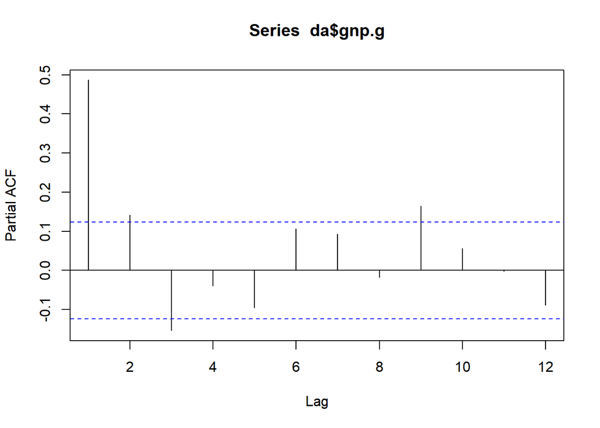

```r
pacf(da$gnp.g,lag=12)
```

#### The ACF and PACF can be quite different.

#### At lag 3, ACF is positive, while PACF is negative. Controling for the impact of lag 1 and lag 2, the impact of lag 3 is negative, though the correlation of lag 3 and original data with out considering the lag 1 and lag 2 is positive.

#### Since the PACF is significant up to lag 3, we use the AR(3) model

#### To call the AR model with lag 3, use the function arima(data,order=c(3,0,0))

```r
m1 = arima(da$gnp.g,order=c(3,0,0))
m1
```

```
##
## Call:
## arima(x = da$gnp.g, order = c(3, 0, 0))
##
## Coefficients:
##          ar1     ar2      ar3  intercept
##       0.4386  0.2063  -0.1559     0.0163
## s.e.  0.0620  0.0666   0.0626     0.0012
##
## sigma^2 estimated as 9.549e-05:  log likelihood = 808.56,  aic = -1607.12
```

## Step 3. Look into the IC to select the AR(p) model

```r
tmp = arima(da$gnp.g,c(3,0,0))
AIC(tmp)
```

```
## [1] -1607.117
```

```r
aic = NULL
bic = NULL
for (i in 0:12){
  tmp = arima(da$gnp.g,c(i,0,0))
  tmpaic = AIC(tmp)
  tmpbic = BIC(tmp)
  aic = append(aic,tmpaic)
  bic = append(bic,tmpbic)
}
```

#### Find the identified order by AIC

```r
# Minus 1 here as we start with order 0
print(paste0("AIC Select Order of ",which(aic==min(aic))-1))
```

```
## [1] "AIC Select Order of 9"
```

```r
print(paste0("BIC Select Order of ",which(bic==min(bic))-1))
```

```
## [1] "BIC Select Order of 3"
```

#### Visualise the AIC and BIC

#### AIC and BIC minus their minimum values for easier visualisation

#### After adjust, AIC and BIC are all greater than 0

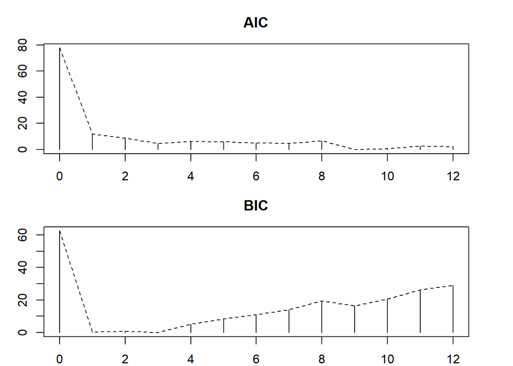

```r
par(mfcol=c(2,1),mar = c(2,3,3,3))

plot(aic-min(aic)~seq(0,length(aic)-1),type='h',
     xlab="",
     ylab="",main='AIC')
lines(seq(0,length(aic)-1),aic-min(aic),lty=2)

plot(bic-min(bic)~seq(0,length(bic)-1),type='h',
     xlab="",
     ylab="",main='BIC')
lines(seq(0,length(bic)-1),bic-min(bic),lty=2)
```

#### Though the criterion identifies an AR(9) model using AIC, but it also gives some justification for an AR(3) model. The plot indicates that AIC would specify an AR(3) model if one focuses on lower order models.

## Step 4. Examine the coefficients of the AR(3) model

```r
gnp.g.ar3 = arima(da$gnp.g,c(3,0,0))
gnp.g.ar3
```

```
##
## Call:
## arima(x = da$gnp.g, order = c(3, 0, 0))
##
## Coefficients:
##          ar1     ar2      ar3  intercept
##       0.4386  0.2063  -0.1559     0.0163
## s.e.  0.0620  0.0666   0.0626     0.0012
##
## sigma^2 estimated as 9.549e-05:  log likelihood = 808.56,  aic = -1607.12
```

```r
gnp.g.ar9 = arima(da$gnp.g,c(9,0,0))
gnp.g.ar9
```

```
##
## Call:
## arima(x = da$gnp.g, order = c(9, 0, 0))
##
## Coefficients:
##          ar1     ar2      ar3     ar4      ar5     ar6     ar7      ar8
##       0.4318  0.1985  -0.1180  0.0189  -0.1607  0.0900  0.0615  -0.0815
## s.e.  0.0617  0.0672   0.0685  0.0689   0.0681  0.0704  0.0702   0.0695
##          ar9  intercept
##       0.1940     0.0160
## s.e.  0.0655     0.0016
##
## sigma^2 estimated as 8.918e-05:  log likelihood = 816.89,  aic = -1611.78
```

#### In R, the Intercept is the unconditional mean of $x_t$, that is $E(x_t) = \dfrac{\phi_0}{1-\phi_1-\phi_2-...-\phi_p}$

## Step 5. Modified AR(9) model

#### From the PACF, the coefficients are only significant at lag 1,2,3,9 but not significant at other lags. So restrict the coefficients at lag 4,5,6,7,8 to 0 in the AR(9) model.

#### The subcommand fixed= enables users to fix parameter values, where NA means estimation and 0 means fixing the parameter to 0. The ordering of the parameters can be found using gnp.g.ar9$coef.

```r
const = rep(NA,10)
const[4:8]=0
gnp.g.ar9.const = arima(da$gnp.g, order = c(9, 0, 0), fixed = const)
gnp.g.ar9.const
```

```
##
## Call:
## arima(x = da$gnp.g, order = c(9, 0, 0), fixed = const)
##
## Coefficients:
##          ar1     ar2      ar3  ar4  ar5  ar6  ar7  ar8     ar9  intercept
##       0.4265  0.2028  -0.1484    0    0    0    0    0  0.1825     0.0159
## s.e.  0.0609  0.0653   0.0612    0    0    0    0    0  0.0575     0.0018
##
## sigma^2 estimated as 9.169e-05:  log likelihood = 813.47,  aic = -1614.94
```

## Step 6. Model checking for residual serial correlations

```r
Box.test(gnp.g.ar3$residuals,lag=12)
```

```
##
##  Box-Pierce test
##
## data:  gnp.g.ar3$residuals
## X-squared = 19.997, df = 12, p-value = 0.06714
```

```r
Box.test(gnp.g.ar9$residuals,lag=12)
```

```
##
##  Box-Pierce test
##
## data:  gnp.g.ar9$residuals
## X-squared = 4.4997, df = 12, p-value = 0.9726
```

```r
Box.test(gnp.g.ar9.const$residuals,lag=12)
```

```
##
##  Box-Pierce test
##
## data:  gnp.g.ar9.const$residuals
## X-squared = 14.801, df = 12, p-value = 0.2525
```

## Step 7. 3 Years(12 Quarter) forecast

```r
gnp.g.f = data.frame(date = da$date,
                     gnp.g = da$gnp.g,
                     pred = da$gnp.g,
                     pred.up = da$gnp.g,
                     pred.bt = da$gnp.g)
head(gnp.g.f)
```

```
##       date      gnp.g       pred    pred.up    pred.bt
## 1 Apr 1947 0.01417872 0.01417872 0.01417872 0.01417872
## 2 Jul 1947 0.01683472 0.01683472 0.01683472 0.01683472
## 3 Oct 1947 0.03990953 0.03990953 0.03990953 0.03990953
## 4 Jan 1948 0.02358509 0.02358509 0.02358509 0.02358509
## 5 Apr 1948 0.02639671 0.02639671 0.02639671 0.02639671
## 6 Jul 1948 0.02426590 0.02426590 0.02426590 0.02426590
```

```r
mf = arima(gnp.g.f$gnp.g,c(3,0,0))
mf$coef
```

```
##         ar1         ar2         ar3   intercept
##  0.43857261  0.20631922 -0.15594606  0.01630425
```

```r
mfpred = predict(mf,n.ahead = 12)

library(lubridate)
testdt = last(gnp.g.f$date)
testdt
```

```
## [1] "Jan 2010"
```

```r
testdt = as.Date(testdt)
testdt
```

```
## [1] "2010-01-01"
```

```r
seq(testdt,by='quarter',length=3)
```

```
## [1] "2010-01-01" "2010-04-01" "2010-07-01"
```

```r
testdt+months(3)
```

```
## [1] "2010-04-01"
```

```r
tmpdt = seq(as.Date(last(gnp.g.f$date))+months(3),by='quarter',length=12)
tmpdt
```

```
##  [1] "2010-04-01" "2010-07-01" "2010-10-01" "2011-01-01" "2011-04-01"
##  [6] "2011-07-01" "2011-10-01" "2012-01-01" "2012-04-01" "2012-07-01"
## [11] "2012-10-01" "2013-01-01"
```

```r
tmpdt = as.yearmon(tmpdt)
tmp = data.frame(date=tmpdt,
                 gnp.g = NA,
                 pred = mfpred$pred,
                 pred.up = mfpred$pred+2*mfpred$se,
                 pred.bt = mfpred$pred-2*mfpred$se)
head(tmp)
```

```
##       date gnp.g       pred    pred.up      pred.bt
## 1 Apr 2010    NA 0.01522904 0.03477248 -0.004314397
## 2 Jul 2010    NA 0.01602850 0.03736888 -0.005311878
## 3 Oct 2010    NA 0.01641477 0.03913295 -0.006303417
## 4 Jan 2011    NA 0.01646350 0.03928204 -0.006355038
## 5 Apr 2011    NA 0.01643990 0.03929041 -0.006410616
## 6 Jul 2011    NA 0.01637937 0.03923118 -0.006472453
```

```r
gnp.g.f = rbind(gnp.g.f,tmp)
gnp.g.f = tail(gnp.g.f,20)
head(gnp.g.f)
```

```
##         date         gnp.g          pred       pred.up       pred.bt
## 245 Apr 2008  0.0086808005  0.0086808005  0.0086808005  0.0086808005
## 246 Jul 2008  0.0028565118  0.0028565118  0.0028565118  0.0028565118
## 247 Oct 2008 -0.0256509182 -0.0256509182 -0.0256509182 -0.0256509182
## 248 Jan 2009 -0.0101793124 -0.0101793124 -0.0101793124 -0.0101793124
## 249 Apr 2009 -0.0005646448 -0.0005646448 -0.0005646448 -0.0005646448
## 250 Jul 2009  0.0082753468  0.0082753468  0.0082753468  0.0082753468
```

```r
tail(gnp.g.f)
```

```
##         date gnp.g       pred    pred.up      pred.bt
## 259 Oct 2011    NA 0.01634035 0.03919296 -0.006512270
## 260 Jan 2012    NA 0.01631443 0.03916932 -0.006540468
## 261 Apr 2012    NA 0.01630445 0.03915979 -0.006550893
## 262 Jul 2012    NA 0.01630081 0.03915636 -0.006554748
## 263 Oct 2012    NA 0.01630120 0.03915676 -0.006554372
## 264 Jan 2013    NA 0.01630217 0.03915774 -0.006553399
```

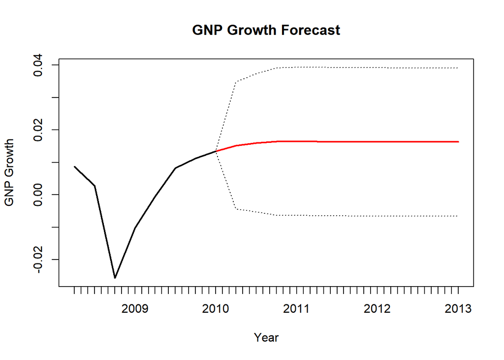

```r
plot(gnp.g.f$pred~gnp.g.f$date,col='red',
     ylim = range(gnp.g.f[,seq(2,5)],na.rm=T),type='l',
     lwd=2,main='GNP Growth Forecast',
     xlab = 'Year',
     ylab = 'GNP Growth')
lines(gnp.g.f$pred.up~gnp.g.f$date,lty=3)
lines(gnp.g.f$pred.bt~gnp.g.f$date,lty=3)
lines(gnp.g.f$gnp.g~gnp.g.f$date,lwd=2)
```

## Step 8. Test for unit root in the GNP data

```r
library(fUnitRoots)
adfTest(da$VALUE)
```

```
##
## Title:
##  Augmented Dickey-Fuller Test
##
## Test Results:
##   PARAMETER:
##     Lag Order: 1
##   STATISTIC:
##     Dickey-Fuller: 6.8346
##   P VALUE:
##     0.99
##
## Description:
##  Tue Nov 12 15:01:44 2019 by user: siche
```

```r
adfTest(da$gnp.g)
```

```
##
## Title:
##  Augmented Dickey-Fuller Test
##
## Test Results:
##   PARAMETER:
##     Lag Order: 1
##   STATISTIC:
##     Dickey-Fuller: -3.3701
##   P VALUE:
##     0.01
##
## Description:
##  Tue Nov 12 15:01:44 2019 by user: siche
```

#### The p value is very large, we cannot reject the H0: A unit root exists.

#### On the other hand, the growth in GNP does not has a unit root.